# HW1_Linux_basics

Author

Nazarii Hrubiian

Published

September 22, 2025

Формат передачі генів (**GTF**) - це формат файлів, який використовується для зберігання інформації про структуру генів. Це текстовий формат з розділенням табуляцією, заснований на форматі загальних ознак (**GFF**), але містить деякі додаткові домовленості, специфічні для генної інформації. Важливою особливістю GTF є те, що його можна перевіряти: маючи послідовність і файл GTF, можна перевірити правильність формату. Це значно зменшує проблеми з обміном даними між групами.

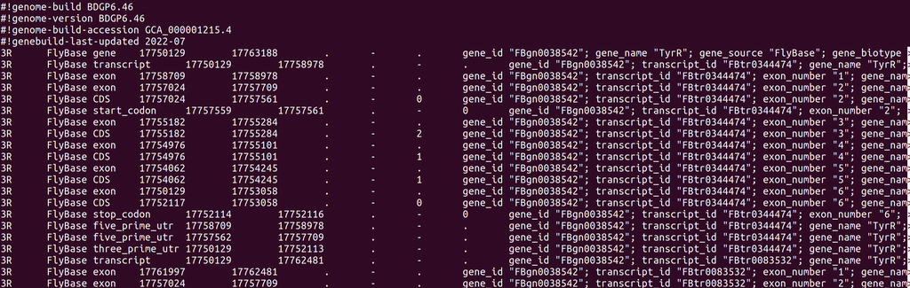

Дані які будемо аналізувати це гени *Drosophila melanogaster* - модельний об’єкт для багатьох генетичних досліджень. Для цього завдання виділено 14 генів *Drosophila melanogster*. Вашим завданням буде проаналізувати їх та виконати вказівки описані нижче.

Список генів:

- **bcd - Гоян +**
- **nos**
- **hb**
- **wg - Загній +**
- **hh - Франчук ++**
- **en - Попадик**
- **m - Жадовець ++**
- **dac - Мельник ++**
- **gl - Джікірба +**
- **ftz**
- **twi - Павлюк +**
- **tim - Мигашко**
- **Pi3K92E - Мадяр ++**
- **InR - Каряка +**

# Опис завдання

Потрібно вияснити:

1. На якій **хромосомі** знаходиться ген
2. **dene_id** знайденого гену
3. **gene_source** гену
4. **Скільки** Елементів(Features) знайдено для цього гену у вигляді екзонів
5. Знайти **найдовший** Елемент(feature)
6. Знайти **найменший** Елемент(feature)
7. Записати всі отримані резульати у вигляді таблички **excel**(приклад додається)
8. **Pro-task(optional)**: написати скрип bash який автоматично виконає завдання(output у вигляді txt з рядками з відповідями через пробіл, приклад додається)

Таблиця з кінцевим результатом матиме вигляд:

[output not shown]

# Крок 1. Завантаження файлу

Для того щоб завантажити файл, використайте команду **curl**

```bash
mkdir genomics_2024     # створення папки в кореневій папці
cd genomics_2024        # Перехід у створену папку
mkdir HW1_Linux_basics  # Створення папки у новоствореній папкці
cd HW1_Linux_basics     # Перезід у новостворену папку
pwd                     # Перевірка шляху створених папкок
# pwd_output: ~/genomics_2024/HW1_Linux_basics/
curl -O https://ftp.ensembl.org/pub/release-112/gtf/drosophila_melanogaster/Drosophila_melanogaster.BDGP6.46.112.gtf.gz # Завантаження GTF файлу референтного геному Drosophila melanogaster
```

# Крок 2. Використання cat, more, less, head, tail для перегляду файлу

```bash
# Перегляд 20 рядків файлу за допомогою команди head
head -n 20 Drosophila_melanogaster.BDGP6.46.112.gtf
# Перегляд останніх 20 рядків файлу за допомогою команди tail
tail -n 20 Drosophila_melanogaster.BDGP6.46.112.gtf
# Перегляд файлу за допомогою less
less -S Drosophila_melanogaster.BDGP6.46.112.gtf
# Перегляд файлу за допомогою more
more Drosophila_melanogaster.BDGP6.46.112.gtf
# Перегляд файлу за допомогою cat
cat Drosophila_melanogaster.BDGP6.46.112.gtf
```

# Крок 3. Пошук гену за допомогою команди grep

```bash
# Використання команди grep для знаходження гену "cpo"
grep \"cpo\" -w Drosophila_melanogaster.BDGP6.46.112.gtf
# Використання команиди wc для підрахунку унікальних Features(кількості рядків) для гена "cpo"
grep \"cpo\" -w Drosophila_melanogaster.BDGP6.46.112.gtf | wc -l
# Підрахунок кількості Features гену "cpo" для екзонів
grep \"cpo\" -w Drosophila_melanogaster.BDGP6.46.112.gtf |grep -w "exon" | wc -l
# Перегляд у зручному форматі за допомогою команди less
grep \"cpo\" -w Drosophila_melanogaster.BDGP6.46.112.gtf |grep -w "exon" | less -S
# Запис відповіді у новий gtf файл
grep \"cpo\" -w Drosophila_melanogaster.BDGP6.46.112.gtf |grep -w "exon" > cpo.gtf
# відображення отриманого результату
less -S cpo.gtf
```

Запишіть кількість Елементів(Features) у excel табличку

# Крок 4. Пошук корисної інформації про розташування гена на хромосомі, gene_id, gene_source

```bash
# Знайти хромосому на якій розташований ген "cpo"
cut -f 1 cpo.gtf | head -n 1
# Пошук gene_id гену "cpo"
cut -f 9 cpo.gtf | cut -d ';' -f 1 | head -n 1
# Пошук gene_source гену "cpo"
cut -f 9 cpo.gtf | cut -d ';' -f 5 | head -n 1
```

Таким чином отримали інформацію про **хромосому**, **gene_id** та **gene_source**. Запишіть отримані результати у Excel табличку

# Крок 5. Знаходження Min та Max елементів(features) гена

```bash
# Оберіть відповідні колонки в яких міститься інформація про початок та кінець транскрипту
cut -f 4,5 cpo.gtf > length_gene.txt
# відніміть значення колонки 2 від колонки 1 та запишіть у новий файл min_max_gene.txt
awk '{print $2 - $1}' length_gene.txt > min_max_gene.txt
# Знайти мінімальне число Елементу(Feature) гена
sort -n min_max_gene.txt | head -n 1
# Знайти максимальне число Елементу(Feature) гена
sort -n min_max_gene.txt | tail -n 1
# Продвинутіший спосіб знаходження min та max
awk 'NR == 1 {min = $1} $1 < min {min = $1} END {print min}' min_max_gene.txt
awk 'NR == 1 {max = $1} $1 > max {max = $1} END {print max}' min_max_gene.txt
```

Запишіть знайдені **min** та **max** довжину Елементів(Features) у табличку

# Крок 6. (Optional) Shell скрипт

Напишіть **shell** скрипт для оптимізації процесу та анотації генів у автоматичному режимі